# Peer Assesment 1

akrosalsky

08/11/2015

### Introduction

It is now possible to collect a large amount of data about personal movement using activity monitoring devices such as a Fitbit, Nike Fuelband, or Jawbone Up. These type of devices are part of the “quantified self” movement – a group of enthusiasts who take measurements about themselves regularly to improve their health, to find patterns in their behavior, or because they are tech geeks. But these data remain under-utilized both because the raw data are hard to obtain and there is a lack of statistical methods and software for processing and interpreting the data.

This assignment makes use of data from a personal activity monitoring device. This device collects data at 5 minute intervals through out the day. The data consists of two months of data from an anonymous individual collected during the months of October and November, 2012 and include the number of steps taken in 5 minute intervals each day.

### Data

The data for this assignment can be downloaded from the course web site:

Dataset: Activity monitoring data [52K]

The variables included in this dataset are:

*steps: Number of steps taking in a 5-minute interval (missing values are coded as NA)

*date: The date on which the measurement was taken in YYYY-MM-DD format

*interval: Identifier for the 5-minute interval in which measurement was taken

The dataset is stored in a comma-separated-value (CSV) file and there are a total of 17,568 observations in this dataset.

### Assignment

Load the data from the CSV file

```r
activity <- read.csv("activity.csv")
library(lattice)
```

#### What is mean total number of steps taken per day?

Calculate total number of steps taken per day, then make a histogram of the total number of steps taken each day

[figure not shown]

```r
daily <- (tapply(activity$steps, activity$date, sum))

daily <- daily[!is.na(daily)]

histogram(~tapply(steps, date, sum),
        data = activity,
        col = 5,
        ylab = "Number of Days",
        xlab = "Total Steps",
        main = "Total Steps per Day",
        breaks = 20)
```

```r
median <- median(daily)

mean <- mean(daily)
```

The mean number of steps taken daily is 10766 steps and the median is 10765 steps.

#### What is the average daily activity pattern?

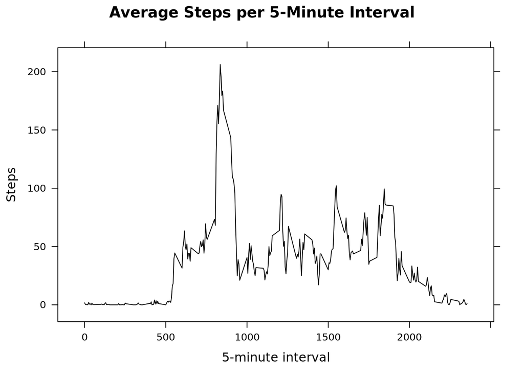

```r
xyplot((tapply(steps[!is.na(steps)], interval[!is.na(steps)], mean)) ~ interval,
        data=activity,
        type="l",
        col = 1,
        xlab = "5-minute interval",
        ylab = "Steps",
        main = "Average Steps per 5-Minute Interval")
```

```r
time <- (tapply(activity$steps[!is.na(activity$steps)], activity$interval
                [!is.na(activity$steps)], mean))
max_steps <- max(time)
max_int <- names(time[time == max_steps])
```

The five-minute interval 835 contains the maximum number of steps, on average, across the dataset. This interval contains an average of 206.1698113 steps.

#### Imputing missing values

```r
missing <- length(activity[is.na(activity)])
```

There are 2304 missing values in the dataset.

To fill in the missing values, the mean for the 5-minute interval will be used. This is being done because there are entire days with no values, so using the mean or median for each day would still result in some days with missing values.

```r
replace_missing <- function(activity){
        interval_means <- tapply(activity$steps[!is.na(activity$steps)],
                                 activity$interval[!is.na(activity$steps)],mean)

        na_index <- which(is.na(activity$steps) == TRUE)

        for (i in na_index){
                interval <- (names(interval_means)==activity$interval[i])
                activity$steps[i] <- as.numeric(interval_means[which(interval)])
        }
        activity
}

new_activity <- replace_missing(activity)
```

##### Histogram

[figure not shown]

```r
histogram(~tapply(steps, date, sum),
        data = new_activity,
        col = 7,
        ylab = "Number of Days",
        xlab = "Total Steps",
        main = "Total Steps per Day",
        breaks = 20)
```

```r
days <- (tapply(new_activity$steps, new_activity$date, sum))

median <- median(days)
mean <- mean(days)
```

With the missing values filled in, the mean number of steps taken daily is 10766 steps and the median is 10766 steps.

#### Are there differences in activity patterns between weekdays and weekends?

```r
days <- sapply(as.Date(new_activity$date), weekdays)
weekend <- c("Saturday", "Sunday")
week <- NULL
for(i in days){
        if (i %in% weekend){
                week <- c(week, "weekend")
        }else{week <- c(week, "weekday")}
}

new_activity[2]<-("date"=week)
```

To determine if there is a difference between activity levels on weekdays and weekends, a new variable must be added to the data frame, separating the data into weekdays and weekends.

```r
library(dplyr)
weekend <- filter(new_activity, new_activity$date == "weekend")
head(weekend)
```

```
##   steps    date interval
## 1     0 weekend        0
## 2     0 weekend        5
## 3     0 weekend       10
## 4     0 weekend       15
## 5     0 weekend       20
## 6     0 weekend       25
```

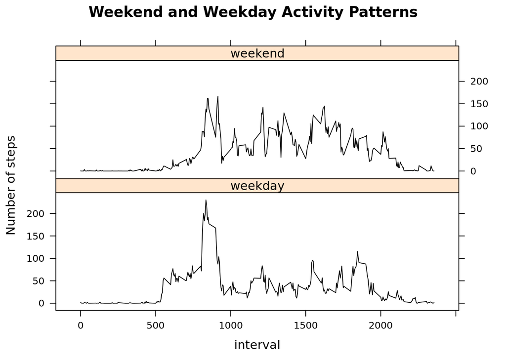

```r
weekend <- tapply(weekend$steps, weekend$interval, mean)

weekday <- filter(new_activity, new_activity$date == "weekday")
weekday <- tapply(weekday$steps, weekday$interval, mean)

week_data <- data.frame("mean" = c(weekend, weekday),
                        "date" = c(rep("weekend", length(weekend)),
                                   rep("weekday", length(weekday))),
                        "interval" = rep(unique(new_activity$interval),2))

xyplot(mean ~ interval | date,
        data = week_data,
        type = "l",
        col = 1,
        layout = c(1,2),
        ylab = "Number of steps",
        main = "Weekend and Weekday Activity Patterns")
```